# Interactions in Regression

Dylan Maddux

2024-09-25

**We will explore the relationship between GDP and terrain ruggedness, and whether that relationship depends on location (specifically, on whether the country in question is located on the continent of Africa). The data were published in 2012 (Nunn and Puga, Review of Economics and Statistics), and contain a large number of measurements, including GDP and an index of terrain ruggedness, for n = 234 countries, although GDP is missing for many of the (mostly smaller) countries. The terrain ruggedness index ranges from 0 (completely flat) to about 6.2 (Lesotho, a very rugged place – three countries have higher ruggedness values, but their GDPs are missing). This data set looks at a streamlined version of the data, with log(GDP) instead of raw GDP.**

```r
library(dplyr)
library(stringr)
library(ggplot2)
```

## Exercise 1

### Part 1: Simple Linear Model

**Question 1** How would you expect that GDP might depend on terrain ruggedness? Do you think that more rugged terrain would be an advantage or a disadvantage in terms of GDP?

```r
rugged <- read.csv('data/RuggedGDP.csv')
rugged <- rugged %>%
  mutate(Africa = str_replace(cont_africa, "1", "Yes")) %>%
  mutate(Africa = str_replace(Africa, "0", "No"))
```

I would expect that economies would function better with flatter terrains due to greater ease of building infrastructure, promoting transportation, and installing agriculture, and therefore that a more rugged terrain would be a disadvantage in terms of GDP.

**Question 2** Make a scatterplot showing log GDP on the Y axis and ruggedness on the X axis. Comment briefly on the appearance of the plot – does there appear to be any relationship?

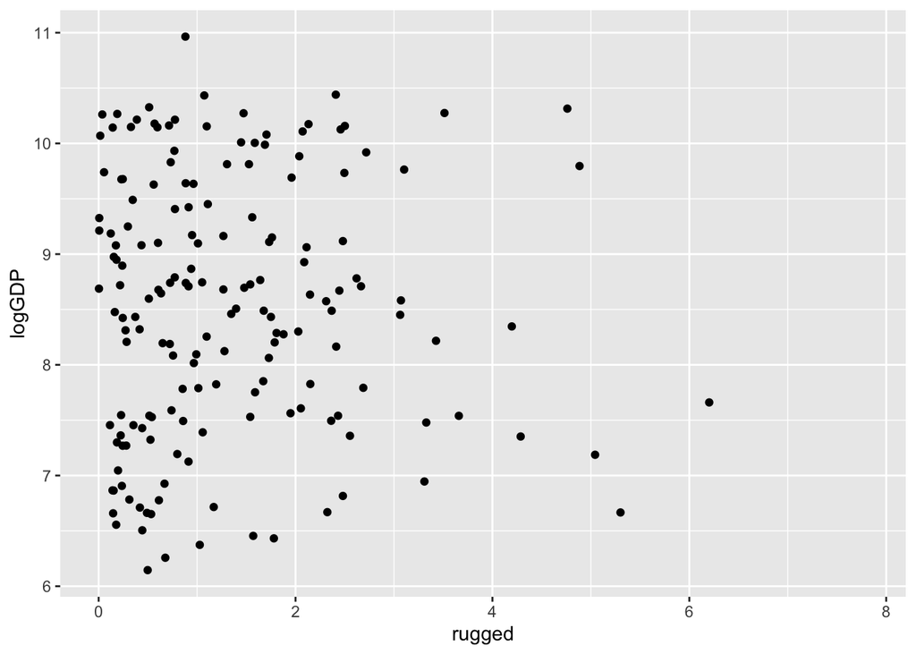

```r
ggplot(rugged, aes(rugged, logGDP)) +
  geom_point()
```

The plot displays a high level of spread and therefore there doesn’t appear to be any relationship.

**Question 3** Fit a simple linear regression model to the data using these two variables. Report the model formula, the t-value and p-value for the slope coefficient, and the R² value. Does it appear that ruggedness is a useful predictor of log GDP?

```r
summary(lm(logGDP~rugged, rugged))
```

```
##
## Call:
## lm(formula = logGDP ~ rugged, data = rugged)
##
## Residuals:
##      Min       1Q   Median       3Q      Max
## -2.36918 -0.98336  0.05727  0.96538  2.44877
##
## Coefficients:
##             Estimate Std. Error t value Pr(>|t|)
## (Intercept) 8.513346   0.136366  62.430   <2e-16 ***
## rugged      0.002829   0.077021   0.037    0.971
## ---
## Signif. codes:  0 '***' 0.001 '**' 0.01 '*' 0.05 '.' 0.1 ' ' 1
##
## Residual standard error: 1.17 on 168 degrees of freedom
##   (64 observations deleted due to missingness)
## Multiple R-squared:  8.029e-06,  Adjusted R-squared:  -0.005944
## F-statistic: 0.001349 on 1 and 168 DF,  p-value: 0.9707
```

**Formula**: logGDP = 0.002829Rugged + 8.513346

**t-value**: 0.037; **p-value**: 0.971; **R²**: 8.029e-06

It appears that ruggedness is not a useful predictor of log GDP.

### Part 2: Separate Intercepts Model

**Question 1** Remake your scatterplot, but this time color the points by whether the country is in Africa or not. Comment briefly on the apparent trends for African and non-African countries.

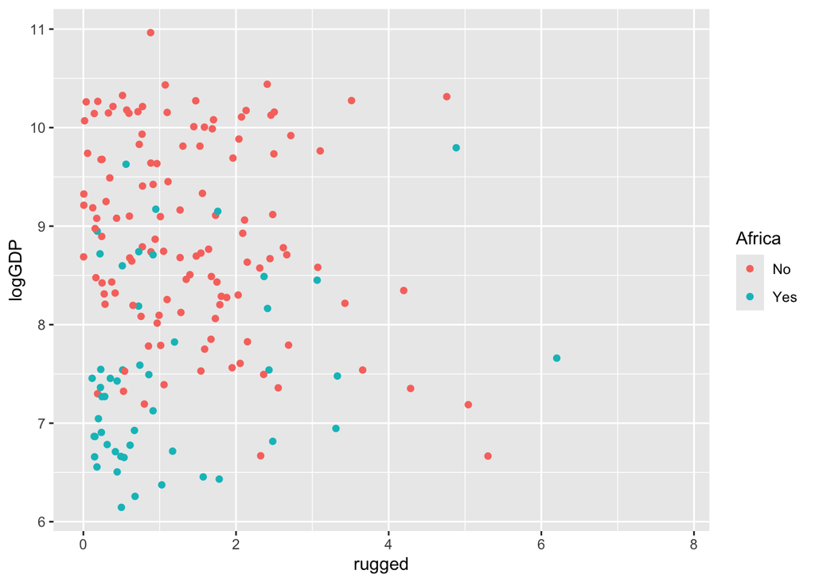

```r
ggplot(rugged, aes(rugged, logGDP, color = as.factor(Africa))) +
  geom_point() +
  labs(color = "Africa")
```

African countries seem to display an increase in GDP with an increase in ruggedness, while non-African countries seem to display a decrease in GDP with an increase in ruggedness.

**Question 2** Add the indicator variable cont_africa (1 = Africa, 0 = other continent) to your regression model. Report the model formula, the t-value and p-value for the coefficients, and the R² value.

```r
summary(lm(logGDP~rugged+Africa, rugged))
```

```
##
## Call:
## lm(formula = logGDP ~ rugged + Africa, data = rugged)
##
## Residuals:
##     Min      1Q  Median      3Q     Max
## -2.2051 -0.7059 -0.1105  0.8705  2.5616
##
## Coefficients:
##             Estimate Std. Error t value Pr(>|t|)
## (Intercept)  9.02962    0.12662  71.312  < 2e-16 ***
## rugged      -0.06687    0.06407  -1.044    0.298
## AfricaYes   -1.46879    0.16481  -8.912 8.34e-16 ***
## ---
## Signif. codes:  0 '***' 0.001 '**' 0.01 '*' 0.05 '.' 0.1 ' ' 1
##
## Residual standard error: 0.966 on 167 degrees of freedom
##   (64 observations deleted due to missingness)
## Multiple R-squared:  0.3223, Adjusted R-squared:  0.3142
## F-statistic: 39.72 on 2 and 167 DF,  p-value: 7.767e-15
```

**t-value**: Rugged (-1.044), Africa (-8.912); **p-value**: Rugged (0.298), Africa (8.34e-16); **R²**: 0.3223

**Question 3** How does the slope coefficient for ruggedness compare to the one in your first model? Does your evaluation of ruggedness as a predictor of log GDP change substantively?

The slope coefficient for ruggedness is now negative, whereas it was positive in the first model. My evaluation of ruggedness as a predictor of log GDP changes slightly since the direction of the relationship changes (albeit not by much), but the p-value still remains not statistically significant.

**Question 4** Based on this model, does it appear that being located in Africa is associated with a change in log GDP? Why or why not? If so, is the estimated change positive or negative?

Based on this model, it appears that being located in Africa is associated with a change in log GDP, because the p-value for this association is a tiny 8.34e-16. The estimated change is negative, in that African countries are more likley to have a lower GDP than non-African countries.

**Question 5** Overall, how does the model fit compare to the simple linear regression model in part 1?

Overall, the model fit is much better due to the lower p-values and higher R² in the model. Adding the variable of whether the country is located in Africa to ‘Ruggedness’ influences the model greatly and makes it a better predictor of GDP.

### Part 3: Adding Interaction

**An interaction between a numeric predictor (ruggedness) and a categorical one (location) allows the slope coefficient of the numeric predictor to vary by levels of the categorical predictor.**

**Question 1** Add the interaction to the model and obtain the summary table.

```r
summary(lm(logGDP~rugged+Africa+rugged:Africa, rugged))
```

```
##
## Call:
## lm(formula = logGDP ~ rugged + Africa + rugged:Africa, data = rugged)
##
## Residuals:
##      Min       1Q   Median       3Q      Max
## -2.08281 -0.74058 -0.05768  0.83096  2.24667
##
## Coefficients:
##                  Estimate Std. Error t value Pr(>|t|)
## (Intercept)       9.22323    0.13965  66.044  < 2e-16 ***
## rugged           -0.20286    0.07739  -2.621  0.00958 **
## AfricaYes        -1.94805    0.22726  -8.572 6.79e-15 ***
## rugged:AfricaYes  0.39339    0.13163   2.989  0.00323 **
## ---
## Signif. codes:  0 '***' 0.001 '**' 0.01 '*' 0.05 '.' 0.1 ' ' 1
##
## Residual standard error: 0.9438 on 166 degrees of freedom
##   (64 observations deleted due to missingness)
## Multiple R-squared:  0.3569, Adjusted R-squared:  0.3453
## F-statistic: 30.71 on 3 and 166 DF,  p-value: 7.595e-16
```

**Question 2** Report the model formula and the R² value. Does the fit of the model improve substantially compared to the previous models?

**R²**: 0.3569

The fit of the model is substantially improved compared to the previous models, since the p-values for both predictor variables are now significant. However, the R² only marginally increased.

**Question 3** Interpret the model coefficients for ruggedness, location in Africa, and their interaction. Using this model, does it appear that terrain ruggedness is a good predictor of log GDP for non-African countries? Does the relationship between log GDP and ruggedness appear to differ for African versus non-African countries? If so, how? Can you think of any reasons for this relationship?

Holding all else constant in the linear model, the log of the GDP decreases by 0.20286 for every 1 unit increase in the ruggedness index, decreases by 1.94805 if the country is located in Africa, while also increasing by 0.39339 for every 1 unit increase in the ruggedness index *if* the country is located in Africa.

Using this model, it appears as though terrain ruggedness is a good predictor of log GDP for non-African countries. The relationship between log GDP and ruggedness appears to differ for African versus non-African countries, as log GDP increases for African countries with greater ruggedness but does not do the same for non-African countries. Perhaps this relationship exists because ruggedness was more advantageous in Africa to offer protection from hostile enemies.

**Question 4** Remake your scatterplot again, this time adding the regression lines for both African and non-African countries.

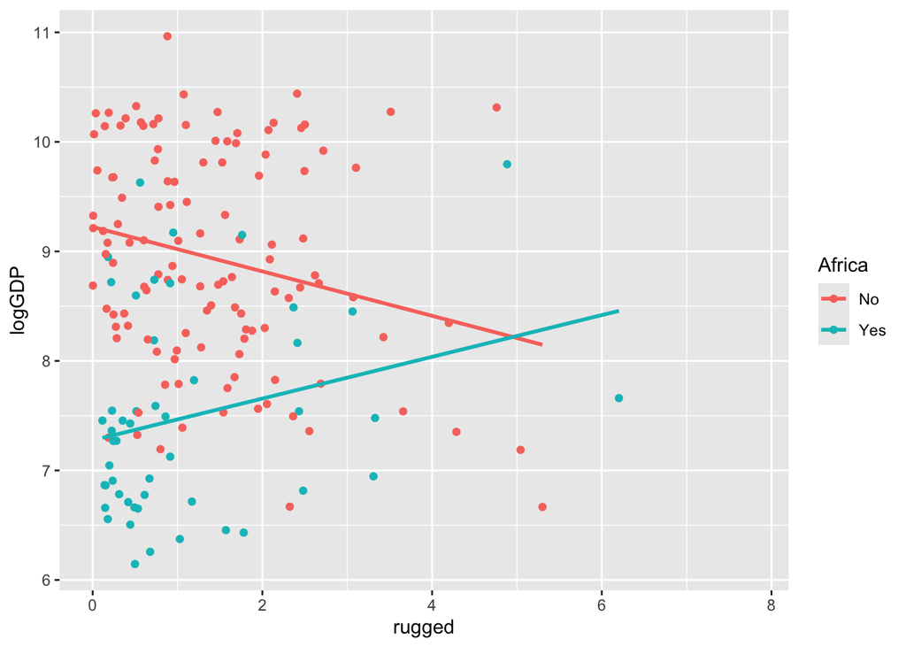

```r
ggplot(rugged, aes(rugged, logGDP, color = as.factor(Africa))) +
  geom_point() +
  geom_smooth(aes(color = as.factor(Africa)), method = "lm", se = F) +
  labs(color = "Africa")
```

## Exercise 2

```r
cars <- read.csv("data/Cars.csv")
```

### Part 1: Interaction Between Numeric Explanatory Variables

**Question 1** Previously, Mileage and Liter were used as numeric predictors to fit a model to predict price. Obtain the summary table and R² value for that regression model.

```r
model1 <- lm(Price~Mileage+Liter, cars)
summary(model1)
```

```
##
## Call:
## lm(formula = Price ~ Mileage + Liter, data = cars)
##
## Residuals:
##    Min     1Q Median     3Q    Max
##  -8817  -4990  -3337   3041  38568
##
## Coefficients:
##               Estimate Std. Error t value Pr(>|t|)
## (Intercept) 9426.60147 1095.07777   8.608  < 2e-16 ***
## Mileage       -0.16003    0.03491  -4.584 5.28e-06 ***
## Liter       4968.27812  258.80114  19.197  < 2e-16 ***
## ---
## Signif. codes:  0 '***' 0.001 '**' 0.01 '*' 0.05 '.' 0.1 ' ' 1
##
## Residual standard error: 8106 on 801 degrees of freedom
## Multiple R-squared:  0.3291, Adjusted R-squared:  0.3275
## F-statistic: 196.5 on 2 and 801 DF,  p-value: < 2.2e-16
```

**Question 2** Add interaction between Mileage and Liter to the model. Obtain the summary table and R² value for this regression model. Does the fit of the model improve substantially? Does the interaction term contribute “significantly” to the model fit?

```r
model2 <- lm(Price~Mileage+Liter+Mileage:Liter, cars)
summary(model2)
```

```
##
## Call:
## lm(formula = Price ~ Mileage + Liter + Mileage:Liter, data = cars)
##
## Residuals:
##    Min     1Q Median     3Q    Max
##  -9609  -5039  -3311   3191  36395
##
## Coefficients:
##                 Estimate Std. Error t value Pr(>|t|)
## (Intercept)   3669.79882 2137.39353   1.717  0.08638 .
## Mileage          0.13038    0.09906   1.316  0.18849
## Liter         6844.85522  652.42025  10.491  < 2e-16 ***
## Mileage:Liter   -0.09493    0.03033  -3.130  0.00181 **
## ---
## Signif. codes:  0 '***' 0.001 '**' 0.01 '*' 0.05 '.' 0.1 ' ' 1
##
## Residual standard error: 8062 on 800 degrees of freedom
## Multiple R-squared:  0.3372, Adjusted R-squared:  0.3348
## F-statistic: 135.7 on 3 and 800 DF,  p-value: < 2.2e-16
```

No, the fit of the model does not improve substantially since the R² value does not change much. The interaction term contributes significantly to the model fit since the p-value is 0.00181.

**Question 3** Interpret the coefficients of this model. How does the coefficient for Mileage change relative to the previous model, and what does this coefficient tell you? What does the coefficient for Liter tell you? What about the interaction coefficient?

Holding all else constant in this model, for every 1 mile increase in Mileage, Price increases by 0.13038; for every 1 unit increase in Engine Size in Liters, Price increases by 6844.865522; and for every 1 unit increase in Engine Size, the effect of Mileage on Price decreases by 0.09493. The coefficient for Mileage is now positive whereas it was negative in the previous model, which tells us that the addition of the interaction term in this model means that greater Mileage itself is associated with a higher price.

**Question 4** We’re using price rather than log price as our response so that we can directly interpret the regression coefficients, and so better understand the interactions. Analyze the diagnostic plots for this model and consider why log price would be better in terms of meeting the conditions for inference.

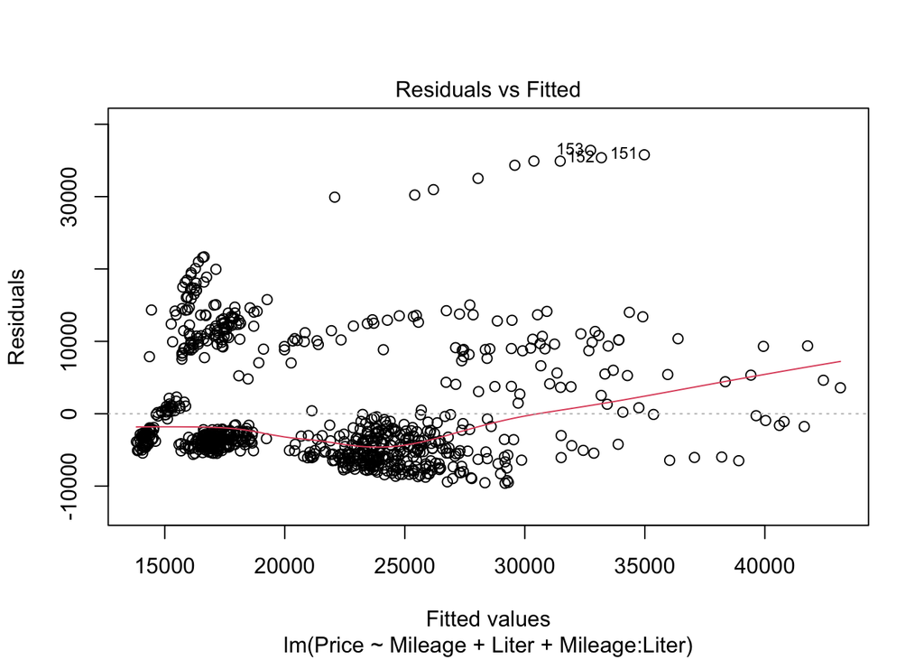

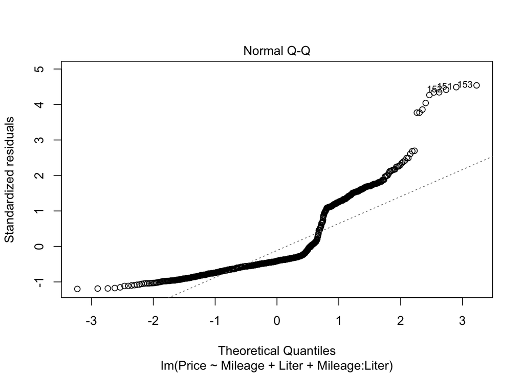

```r
plot(model2, 1:2)
```

The heavily right-skewed distribution of the Q-Q plot and substantial outliers suggest that a logarithmic transformation would probably be better in terms of meeting the conditions for inference since the extreme values on the end ranges would be reduced.

### Part 2

**Question 1** Previously, you fit a model to predict price using Mileage and Cyl as numeric predictors. Obtain the summary table and R² value for that regression model.

```r
model3 <- lm(Price~Mileage+Cyl, cars)
summary(model3)
```

```
##
## Call:
## lm(formula = Price ~ Mileage + Cyl, data = cars)
##
## Residuals:
##    Min     1Q Median     3Q    Max
## -10264  -5121  -2838   3102  35477
##
## Coefficients:
##               Estimate Std. Error t value Pr(>|t|)
## (Intercept) 3145.75032 1325.93436   2.372   0.0179 *
## Mileage       -0.15243    0.03464  -4.401 1.22e-05 ***
## Cyl         4027.67463  204.61180  19.684  < 2e-16 ***
## ---
## Signif. codes:  0 '***' 0.001 '**' 0.01 '*' 0.05 '.' 0.1 ' ' 1
##
## Residual standard error: 8042 on 801 degrees of freedom
## Multiple R-squared:  0.3398, Adjusted R-squared:  0.3382
## F-statistic: 206.2 on 2 and 801 DF,  p-value: < 2.2e-16
```

**Question 2** Add interaction between Mileage and Cyl to the model, using Cyl as a numeric variable for the moment. Obtain the summary table and R² value for the regression model. Does the interaction term contribute “significantly” to the model fit? Interpret the coefficients of this model.

```r
model4 <- lm(Price~Mileage+Cyl+Mileage:Cyl, cars)
summary(model4)
```

```
##
## Call:
## lm(formula = Price ~ Mileage + Cyl + Mileage:Cyl, data = cars)
##
## Residuals:
##    Min     1Q Median     3Q    Max
## -10848  -5034  -2789   3407  32425
##
## Coefficients:
##               Estimate Std. Error t value Pr(>|t|)
## (Intercept) -5.280e+03  2.836e+03  -1.862 0.063029 .
## Mileage      2.718e-01  1.310e-01   2.074 0.038418 *
## Cyl          5.612e+03  5.142e+02  10.915  < 2e-16 ***
## Mileage:Cyl -8.002e-02  2.385e-02  -3.355 0.000832 ***
## ---
## Signif. codes:  0 '***' 0.001 '**' 0.01 '*' 0.05 '.' 0.1 ' ' 1
##
## Residual standard error: 7991 on 800 degrees of freedom
## Multiple R-squared:  0.349,  Adjusted R-squared:  0.3465
## F-statistic: 142.9 on 3 and 800 DF,  p-value: < 2.2e-16
```

The interaction term does contribute significantly to the model fit since the p-value is 0.000832. Holding all else constant in this model, each unit increase in Mileage is associated with a 0.27178 increase in Price, each unit increase in the number of Cylinders is associated with a 5611.9686 increase in Price, and each unit increase in Mileage is associated with a 0.08002 decrease of the effect of the number of Cylinders on Price.

**Question 3** Since there are only three values of Cyl in the data set, convert it to a categorical (“factor”) variable rather than a numeric linear predictor.

```r
CarsNew = mutate(cars, Cyl6 = ifelse(Cyl == 6, 1, 0),
                 Cyl8 = ifelse(Cyl == 8, 1, 0),
                 Cylinders = as.factor(Cyl))
```

**Question 4** Fit a model with Mileage and Cylinders as the explanatory variables, and obtain the summary table and R² value. Compare this to to your model in Question #1 above, using Cyl as a numeric predictor. Which model fits the data better?

```r
model5 <- lm(Price~Mileage+Cylinders, CarsNew)
summary(model5)
```

```
##
## Call:
## lm(formula = Price ~ Mileage + Cylinders, data = CarsNew)
##
## Residuals:
##    Min     1Q Median     3Q    Max
## -16843  -4460  -2559   2555  28763
##
## Coefficients:
##               Estimate Std. Error t value Pr(>|t|)
## (Intercept)  2.106e+04  7.153e+02  29.448  < 2e-16 ***
## Mileage     -1.592e-01  3.075e-02  -5.178 2.84e-07 ***
## Cylinders6   2.132e+03  5.422e+02   3.932 9.14e-05 ***
## Cylinders8   2.102e+04  7.995e+02  26.293  < 2e-16 ***
## ---
## Signif. codes:  0 '***' 0.001 '**' 0.01 '*' 0.05 '.' 0.1 ' ' 1
##
## Residual standard error: 7138 on 800 degrees of freedom
## Multiple R-squared:  0.4804, Adjusted R-squared:  0.4785
## F-statistic: 246.6 on 3 and 800 DF,  p-value: < 2.2e-16
```

This model appears to fit the data better since the R² increased from 33.98% to 48.04% from the previous model, and the p-values for Mileage and the intercept decreased as well.

**Question 5** Interpret the coefficients of the new model with Mileage and Cylinders as predictors of price. What is the predicted price of a new car (Mileage = 0) with 4 cylinders, 6 cylinders, and 8 cylinders?

Holding all else constant, each unit increase in Mileage is associated with a 0.15923 decrease in Price, while cars with 6 cylinders increase the average price by $2,132.10 and cars with 8 cylinders increase the price by $21,020.62. The predicted price of a new car with 4 cylinders is ‘21064.46153 + 0’ = $21,064.46, a new car with 6 cylinders is ‘21064.46153 + 2132.09803’ = $23,196.56, and a new car with 8 cylinders is ‘21064.46153 + 21020.62242’ = $42,085.08.

**Question 6** Refit the model with Mileage, Cyl6, and Cyl8 as the predictors.

```r
model6 <- lm(Price~Mileage+Cyl6+Cyl8, CarsNew)
summary(model6)
```

```
##
## Call:
## lm(formula = Price ~ Mileage + Cyl6 + Cyl8, data = CarsNew)
##
## Residuals:
##    Min     1Q Median     3Q    Max
## -16843  -4460  -2559   2555  28763
##
## Coefficients:
##               Estimate Std. Error t value Pr(>|t|)
## (Intercept)  2.106e+04  7.153e+02  29.448  < 2e-16 ***
## Mileage     -1.592e-01  3.075e-02  -5.178 2.84e-07 ***
## Cyl6         2.132e+03  5.422e+02   3.932 9.14e-05 ***
## Cyl8         2.102e+04  7.995e+02  26.293  < 2e-16 ***
## ---
## Signif. codes:  0 '***' 0.001 '**' 0.01 '*' 0.05 '.' 0.1 ' ' 1
##
## Residual standard error: 7138 on 800 degrees of freedom
## Multiple R-squared:  0.4804, Adjusted R-squared:  0.4785
## F-statistic: 246.6 on 3 and 800 DF,  p-value: < 2.2e-16
```

The output displays the exact same estimates and p-values as from the model with ‘Mileage’ and ‘Cylinders’.

**Question 7** Fit a model with Mileage, Cylinders, and their interactions as predictors, and obtain the summary table and R² value. Does the interaction contribute “significantly” to the model fit? Interpret the coefficients of this model.

```r
model7 <- lm(Price~Mileage+Cylinders+Mileage:Cylinders, CarsNew)
summary(model7)
```

```
##
## Call:
## lm(formula = Price ~ Mileage + Cylinders + Mileage:Cylinders,
##     data = CarsNew)
##
## Residuals:
##    Min     1Q Median     3Q    Max
## -16788  -4488  -2431   2589  25190
##
## Coefficients:
##                      Estimate Std. Error t value Pr(>|t|)
## (Intercept)         1.944e+04  9.414e+02  20.648  < 2e-16 ***
## Mileage            -7.839e-02  4.333e-02  -1.809 0.070778 .
## Cylinders6          3.812e+03  1.430e+03   2.666 0.007831 **
## Cylinders8          2.787e+04  1.955e+03  14.256  < 2e-16 ***
## Mileage:Cylinders6 -8.363e-02  6.694e-02  -1.249 0.211919
## Mileage:Cylinders8 -3.475e-01  9.070e-02  -3.831 0.000138 ***
## ---
## Signif. codes:  0 '***' 0.001 '**' 0.01 '*' 0.05 '.' 0.1 ' ' 1
##
## Residual standard error: 7082 on 798 degrees of freedom
## Multiple R-squared:  0.4898, Adjusted R-squared:  0.4866
## F-statistic: 153.2 on 5 and 798 DF,  p-value: < 2.2e-16
```

**Question 8** Which of the models you’ve considered in this exercise seems most useful for predicting the price of a used car?

Of the models we’ve considered in this exercise, the model with ‘Mileage’ and the categorical variable of ‘Cylinders’ as predictors of price seems most useful for predicting the price of a used car. This model had a strong R² value of 48.04%, while all the p-values of the variables were statistically significant.